# MLB Prospects

Guy Spurrier

2018-01-12

Daren Willman, the baseball database hobbyist who turned his avocation into a job as the director of baseball research & development for Major League Baseball, tweeted yesterday a list of teams and the number of prospects they currently have in MLB Pipeline’s top 100.

At the top of the chart, the Braves, Brewers, Padres and Rays all have seven players on the list, while the Cubs, Giants, Marlins, Mets and Royals aren’t listed because they don’t have any ranked prospects.

The chart below visualizes the ranking of each team’s prospect to give a snapshot of quantity and rank quality. The names of the top six prospects and the Blue Jays’ prospects also are shown.

```r
# MLB Pipeline top 100 prospects as retrieved Jan. 10, 2018 snapshot

library(tidyverse)
library(readr)
library(RColorBrewer)

# move this data to Github and provide a new filepath
mlb100 <- read_csv("~/Documents/R/Data files/Baseball/MLBPipeline_100prospects_20180110.txt")
```

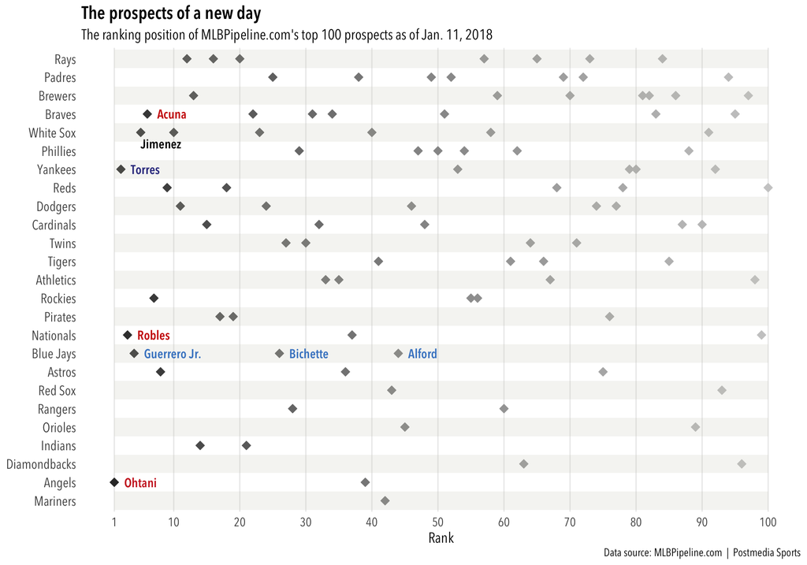

```r
# recount the prospects by team to verify the data Willman tweeted
prosCount <- count(mlb100, Team)

# add a new column of the count totals to provide a sorting order later
mlb100$Count <- c(2, 5, 3, 3, 6, 7, 3, 3, 5, 6, 5, 7, 7, 2, 5, 7, 3, 5, 3, 7, 2, 7, 6, 5, 7, 3, 4, 2, 6, 4, 7, 5, 4, 7, 4, 3, 3, 7, 2, 6, 4, 1, 2, 3, 2, 5, 6, 5, 7, 6, 7, 7, 5, 6, 3, 3, 7, 6, 7, 2, 4, 6, 2, 4, 7, 4, 4, 5, 7, 7, 4, 7, 7, 5, 3, 3, 5, 5, 5, 5, 7, 7, 7, 7, 4, 7, 5, 6, 2, 5, 6, 5, 2, 7, 7, 2, 7, 4, 3, 5)

# puts the fonts I use into a variable
quartzFonts(ANXTC = c("Avenir Next Condensed Regular", "Avenir Next Condensed Demi Bold", "Avenir Next Condensed Italic", "Avenir Next Condensed Demi Bold Italic"))

# plot the data
ggplot(mlb100) +
  geom_point(aes(x = Rank, y = reorder(Team, +Count), colour = factor(Rank), fill = factor(Rank)), shape = 23, size = 2.5) +
  theme_minimal() +
  theme(text = element_text(family = "ANXTC"), plot.title = element_text(size = 16, face = "bold"), plot.subtitle = element_text(size = 13, face = "plain"), axis.title.x = element_text(size = 13, face = "plain"), axis.title.y = element_text(size = 13, face = "plain"), legend.direction = "horizontal", legend.position = "top", axis.text.x = element_text(size = 11, face = "plain"), axis.text.y = element_text(size = 12, face = "plain"), panel.grid.major.y = element_blank()) +
  labs(title = "The prospects of a new day", subtitle = "The ranking position of MLBPipeline.com's top 100 prospects as of Jan. 11, 2018", x = "Rank", y = NULL, caption = "Data source: MLBPipeline.com  |  Postmedia Sports") +
  scale_colour_grey(guide = FALSE) +
  scale_fill_grey(guide = FALSE) +
  scale_x_continuous(breaks = c(1,10,20,30,40,50,60,70,80,90,100), minor_breaks = NULL) +
  annotate("text", x = c(5.5,27.5,45.5), y = c(9,9,9), label = c("Guerrero Jr.", "Bichette", "Alford"), colour = "dodgerblue3", size = 4, hjust = 0, family = "ANXTC", fontface = "bold") +
  annotate("text", x = c(2.5,3.5,4.5,5,7.5), y = c(2,19,10,20.4,22), label = c("Ohtani","Torres","Robles","Jimenez","Acuna"), colour = c("firebrick3","navy","red3","black","red3"), size = 4, hjust = 0, family = "ANXTC", fontface = "bold") +
  annotate("rect", xmin = rep_len(1, 13), xmax = rep_len(100, 13), ymin = c(0.5,2.5,4.5,6.5,8.5,10.5,12.5,14.5,16.5,18.5,20.5,22.5,24.5), ymax = c(1.5,3.5,5.5,7.5,9.5,11.5,13.5,15.5,17.5,19.5,21.5,23.5,25.5), fill = "ivory3", alpha = 0.2)
```

Preparing a plot for the National Post’s WordPress means being able to work within a 640px-wide space. Given the relative roominess of the plot above, I would consider adding the players’ first names in the future.

MLB Pipeline promises a new ranking for the start of the 2018 season on Jan. 27. I expect to re-run this plot with the addition of the new ranking, to see the changes in team counts and distributions.

There’s some talk the Jays’ Bo Bichette could rise from No. 26 and it seems possible Anthony Alford could graduate from the list into the majors this season after he continued to tear up pitching with Jalisco in the Mexican Pacific Winter League (.343 average, .373 on-base, .816 OPS) before being shut down.

The original publication of this plot can be found here: http://bit.ly/2DkmxAX